# Finding and Using Negotiation Power

Session 1

Luis F. Gómez L.

luis.gomezl@unimilitar.edu.co

Distance Learning Faculty

8 September, 2026

# Please Read Me

- Check the message **Welcome greeting** published in the News Bulletin Board.
- Dear student please edit your profile uploading a photo where your face is clearly visible.
- The purpose of the virtual meetings is to answer questions and not to make a summary of the study material.
- This presentation is based on (Lewicki et al., 2024, Chapter 8)
- **Purpose**
  - Understand the role of power and the diverse sources from which bargaining leverage arises in a negotiation.

# Power in the context of a negotiation

- Power in the context of a negotiation refers to the ability of a negotiator to gain an advantage or increase the likelihood of approaching its target point.
- Power is important in a negotiation because it generates advantages and allows reaching a settlement point close to the target point.

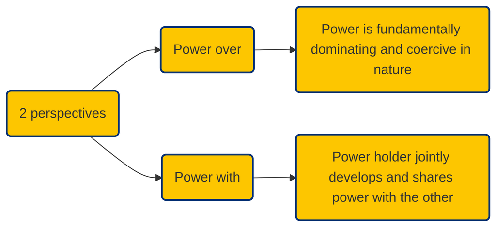

Figure 1: Perspectives about power[^1]

# Sources of power in a negotiation

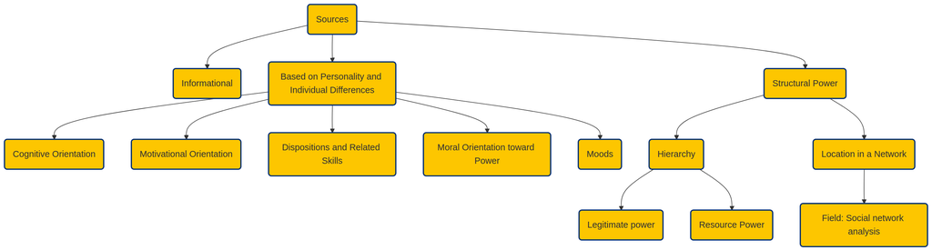

Figure 2: Sources of power in a negotiation (Lewicki et al., 2024, pp. 242–260)

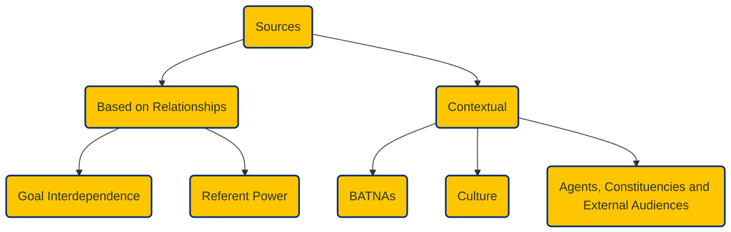

Figure 3: Sources of power in a negotiation (Lewicki et al., 2024, pp. 242–260)

# The Consequences of Unequal Power

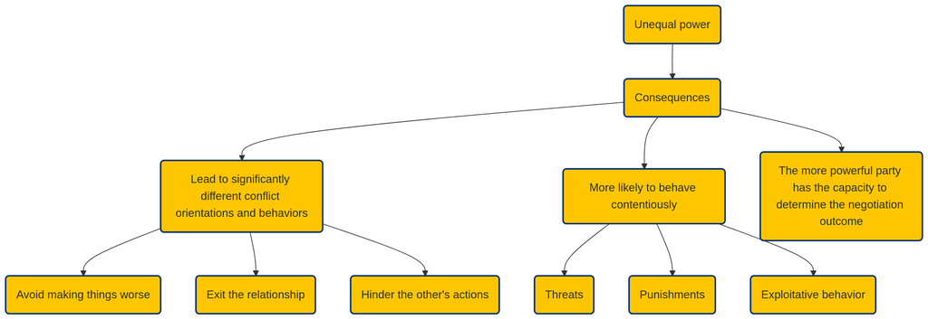

Figure 4: Consequences of unequal power in a negotiation (Lewicki et al., 2024, pp. 260–261)

# Dealing with negotatiors how have more power

- Advice to negotiators who are in low-power positions based on (Lewicki et al., 2024, pp. 261–262):
  - Diversify risk by entering into deals with several other partners.
  - Deal with a variety of different individuals and departments in the high-power party (Divide and Conquer).
  - Build coalitions with other low-power players to increase collective bargaining power.
  - Enter in early deals with high-power parties and maximize the visibility of those deals to other parties.
- Advice to negotiators who are in low-power positions based on (Lewicki et al., 2024, pp. 261–262):
  - If you have something to offer, make sure you offer it to more than one high-power party to generate competition between them.
  - Gather and leverage relevant information to strengthen your negotiation position and achieve better outcomes through persuasive communication.
  - Do what you can to manage the process (for example the agenda or location) to guide the negotiation towards a more favorable outcome.

# Acknowledgments

- To my family that supports me
- To the taxpayers of Colombia and the [**UMNG students**](https://www.umng.edu.co/estudiante) who pay my salary
- To the [**Business Science**](https://www.business-science.io/) and [**R4DS Online Learning**](https://www.rfordatasci.com/) communities where I learn [**R**](https://www.r-project.org/about.html) and [**$\pi$-thon**](https://www.python.org/about/)
- To the [**R Core Team**](https://www.r-project.org/contributors.html), the creators of [**RStudio IDE**](https://rstudio.com/products/rstudio/), [**Quarto**](https://quarto.org/) and the authors and maintainers of the packages [**tinytex**](https://CRAN.R-project.org/package=tinytex) for allowing me to access these tools without paying for a license

# References

Coleman, P. T. (2014). Power and Conflict. In *The Handbook of Conflict Resolution: Theory and Practice* (3rd ed., pp. 137–181). Jossey-Bass.

Lewicki, R. J., Barry, B., & Saunders, D. M. (2024). *Negociación* (9th ed.). McGraw-Hill Education. https://www-ebooks7-24-com.ezproxy.umng.edu.co/?il=40562

## Footnotes

[^1]: Check out (Coleman, 2014) if you want a general perspective about power and its relation with conflict